# AttBli Notebook

TODO: check on EOL warnings from csv file

# Attentional Blink PRE DATA ANALYSIS

## Data Prep

Getting the Data ready for analysis Defaults: R uses dummy coding as it’s default. In this sample, the control group and the 1-Back will be the dummy variables in the analysis. So all Estimates are relative to these dummy variables

### Load Requisite R Packages

note: some of these may not actually be used.

```r
library(ggplot2)
library(lme4)
library(languageR)
library(lmerTest)
library(influence.ME)
```

### Read in the dataset (in current directory)

```r
AttBli_data = read.table("AttBli_R_format.csv",
header = TRUE, sep = ",")
```

### Omit missing data (e.g. from practice trials)

```r
AttBli_data= na.omit(AttBli_data)
head(AttBli_data, n = 20)
```

```
##    subject session        group stimtype letter_ACC letter_RT probe_ACC
## 41       5       1 Experimental       -1          1      2591         1
## 42       5       1 Experimental        8          1      1212         1
## 43       5       1 Experimental        8          1      1264         1
## 44       5       1 Experimental       -1          1      1424         1
## 45       5       1 Experimental        8          1      1784         1
## 46       5       1 Experimental        8          1      1038         1
## 47       5       1 Experimental       -1          1      1167         1
## 48       5       1 Experimental        2          1      1087         1
## 49       5       1 Experimental       -1          1      1044         1
## 50       5       1 Experimental        4          1      1066         1
## 51       5       1 Experimental        8          1      1697         1
## 52       5       1 Experimental       -1          1      1286         1
## 53       5       1 Experimental        2          1      1193         0
## 54       5       1 Experimental        2          1       925         1
```

[output cut: 27 more lines]

### Omit the Undefined group from the data and specify group as a factor

```r
AttBli_data <- subset(AttBli_data,group=="Control" | group=="Experimental")
AttBli_data$group <- factor(AttBli_data$group)
summary(AttBli_data)
```

```
##     subject         session               group         stimtype
##  Min.   :  5.0   Min.   :1.000   Control     :8928   Min.   :-1.0
##  1st Qu.: 45.0   1st Qu.:1.000   Experimental:8064   1st Qu.:-1.0
##  Median : 98.0   Median :1.000                       Median : 0.5
##  Mean   :105.2   Mean   :1.475                       Mean   : 2.0
##  3rd Qu.:166.0   3rd Qu.:2.000                       3rd Qu.: 4.5
##  Max.   :209.0   Max.   :2.000                       Max.   : 8.0
##    letter_ACC       letter_RT       probe_ACC         probe_RT
##  Min.   :0.0000   Min.   :   60   Min.   :0.0000   Min.   :   74.0
##  1st Qu.:1.0000   1st Qu.: 1108   1st Qu.:1.0000   1st Qu.:  431.0
##  Median :1.0000   Median : 1326   Median :1.0000   Median :  617.0
##  Mean   :0.9615   Mean   : 1507   Mean   :0.7847   Mean   :  786.3
##  3rd Qu.:1.0000   3rd Qu.: 1638   3rd Qu.:1.0000   3rd Qu.:  897.0
##  Max.   :1.0000   Max.   :32574   Max.   :1.0000   Max.   :24138.0
```

```r
contrasts(AttBli_data$group)
```

```
##              Experimental
## Control                 0
## Experimental            1
```

### Isolate the session to the first session

```r
AttBli_data_pre <- subset(AttBli_data, session==1)
AttBli_data_pre$session <- factor(AttBli_data_pre$session)
summary(AttBli_data_pre)
```

```
##     subject    session           group         stimtype
##  Min.   :  5   1:8928   Control     :4752   Min.   :-1.0
##  1st Qu.: 51            Experimental:4176   1st Qu.:-1.0
##  Median :100                                Median : 0.5
##  Mean   :107                                Mean   : 2.0
##  3rd Qu.:172                                3rd Qu.: 4.5
##  Max.   :209                                Max.   : 8.0
##    letter_ACC       letter_RT       probe_ACC         probe_RT
##  Min.   :0.0000   Min.   :   60   Min.   :0.0000   Min.   :  140.0
##  1st Qu.:1.0000   1st Qu.: 1125   1st Qu.:1.0000   1st Qu.:  454.0
##  Median :1.0000   Median : 1345   Median :1.0000   Median :  660.5
##  Mean   :0.9575   Mean   : 1553   Mean   :0.7678   Mean   :  864.6
##  3rd Qu.:1.0000   3rd Qu.: 1676   3rd Qu.:1.0000   3rd Qu.: 1029.0
##  Max.   :1.0000   Max.   :30189   Max.   :1.0000   Max.   :24138.0
```

### Specify subject as a factor

```r
AttBli_data_pre$subject <- as.factor(AttBli_data_pre$subject)

summary(AttBli_data_pre)
```

```
##     subject     session           group         stimtype
##  5      : 144   1:8928   Control     :4752   Min.   :-1.0
##  6      : 144            Experimental:4176   1st Qu.:-1.0
##  8      : 144                                Median : 0.5
##  9      : 144                                Mean   : 2.0
##  10     : 144                                3rd Qu.: 4.5
##  11     : 144                                Max.   : 8.0
##  (Other):8064
##    letter_ACC       letter_RT       probe_ACC         probe_RT
##  Min.   :0.0000   Min.   :   60   Min.   :0.0000   Min.   :  140.0
##  1st Qu.:1.0000   1st Qu.: 1125   1st Qu.:1.0000   1st Qu.:  454.0
##  Median :1.0000   Median : 1345   Median :1.0000   Median :  660.5
##  Mean   :0.9575   Mean   : 1553   Mean   :0.7678   Mean   :  864.6
##  3rd Qu.:1.0000   3rd Qu.: 1676   3rd Qu.:1.0000   3rd Qu.: 1029.0
##  Max.   :1.0000   Max.   :30189   Max.   :1.0000   Max.   :24138.0
##
```

### Specify stimtype (probe in relation to cue) as a factor

Note: could treat this as a continuous variable instead of a discrete factor, up for debate. stimtype(-1,2,4,6,8)

```r
AttBli_data_pre$stimtype <- as.factor(AttBli_data_pre$stimtype)
summary(AttBli_data_pre)
```

```
##     subject     session           group      stimtype    letter_ACC
##  5      : 144   1:8928   Control     :4752   -1:4464   Min.   :0.0000
##  6      : 144            Experimental:4176   2 :1116   1st Qu.:1.0000
##  8      : 144                                4 :1116   Median :1.0000
##  9      : 144                                6 :1116   Mean   :0.9575
##  10     : 144                                8 :1116   3rd Qu.:1.0000
##  11     : 144                                          Max.   :1.0000
##  (Other):8064
##    letter_RT       probe_ACC         probe_RT
##  Min.   :   60   Min.   :0.0000   Min.   :  140.0
##  1st Qu.: 1125   1st Qu.:1.0000   1st Qu.:  454.0
##  Median : 1345   Median :1.0000   Median :  660.5
##  Mean   : 1553   Mean   :0.7678   Mean   :  864.6
##  3rd Qu.: 1676   3rd Qu.:1.0000   3rd Qu.: 1029.0
##  Max.   :30189   Max.   :1.0000   Max.   :24138.0
##
```

## AttBli Accuracy Analysis

### Print out accuracy data for each subject for each group

Note: This is without filtering for whether the participant got the letter cue right or not.

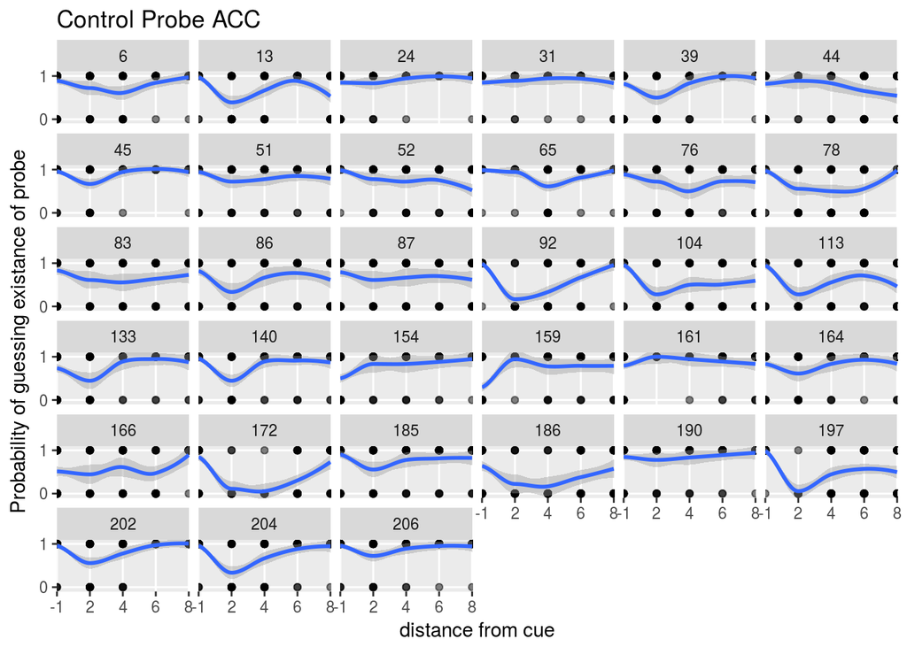

```r
#subset data by experimental and control groups
AttBli_data_pre_control <- subset(AttBli_data_pre, group=="Control")
AttBli_data_pre_experimental <- subset(AttBli_data_pre, group=="Experimental")

#print control group data
g1 <- ggplot(data = AttBli_data_pre_control, aes(x = as.numeric(AttBli_data_pre_control$stimtype), y = AttBli_data_pre_control$probe_ACC))
g2 <- g1 + geom_point(alpha=.5) + geom_smooth(method='loess')
g3 <- g2 + scale_x_discrete(name = "distance from cue", limits=c("-1","2","4","6","8"))
g4 <- g3 + scale_y_discrete(name = "Probability of guessing existance of probe", limits=c(0,1))
g5 <- g4 + coord_cartesian(ylim =c(-.1,1.1), expand = FALSE) + facet_wrap(~subject) + ggtitle("Control Probe ACC")
print(g5)
```

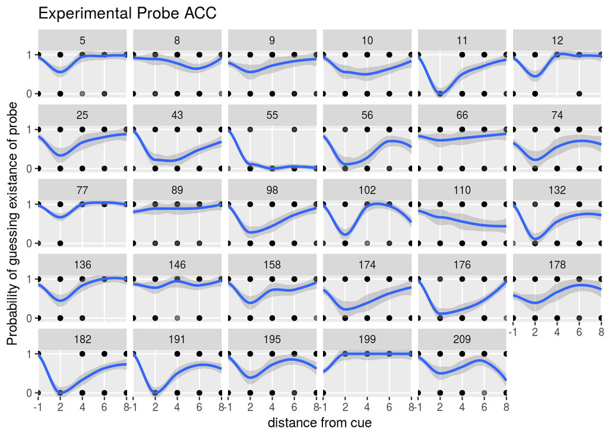

```r
#print experimental group data
g1 <- ggplot(data = AttBli_data_pre_experimental, aes(x = as.numeric(AttBli_data_pre_experimental$stimtype), y = AttBli_data_pre_experimental$probe_ACC))
g2 <- g1 + geom_point(alpha=.5) + geom_smooth(method='loess')
g3 <- g2 + scale_x_discrete(name = "distance from cue", limits=c("-1","2","4","6","8"))
g4 <- g3 + scale_y_discrete(name = "Probability of guessing existance of probe", limits=c(0,1))
g5 <- g4 + coord_cartesian(ylim =c(-.1,1.1), expand = FALSE) + facet_wrap(~subject) + ggtitle("Experimental Probe ACC")
print(g5)
```

**Conclusion**: While a majority of the subjects show the expected pattern, many do not fit the pattern, or do not fit the pattern well. The next section will graph the results restricting them to only trials where the participant got the cue letter correct.

### Print out accuracy data for each subject for each group (filtering for letter cue accuracy)

Graphs where we only look at probe accuracy when the participant got the cue correct (matches the concept of attentional blink better)

[figure not shown]

```r
AttBli_data_pre_cue_filter <- subset(AttBli_data_pre, letter_ACC=="1")
#subset data by experimental and control groups
AttBli_data_pre_cue_filter_control <- subset(AttBli_data_pre_cue_filter, group=="Control")
AttBli_data_pre_cue_filter_experimental <- subset(AttBli_data_pre_cue_filter, group=="Experimental")

#print control group data
g1 <- ggplot(data = AttBli_data_pre_cue_filter_control, aes(x = as.numeric(stimtype), y = probe_ACC))
g2 <- g1 + geom_point(alpha=.5) + geom_smooth(method='loess')
g3 <- g2 + scale_x_discrete(name = "distance from cue", limits=c("-1","2","4","6","8"))
g4 <- g3 + scale_y_discrete(name = "Probability of guessing existance of probe", limits=c(0,1))
g5 <- g4 + coord_cartesian(ylim =c(-.1,1.1), expand = FALSE) + facet_wrap(~subject) + ggtitle("Control Probe ACC")
print(g5)
```

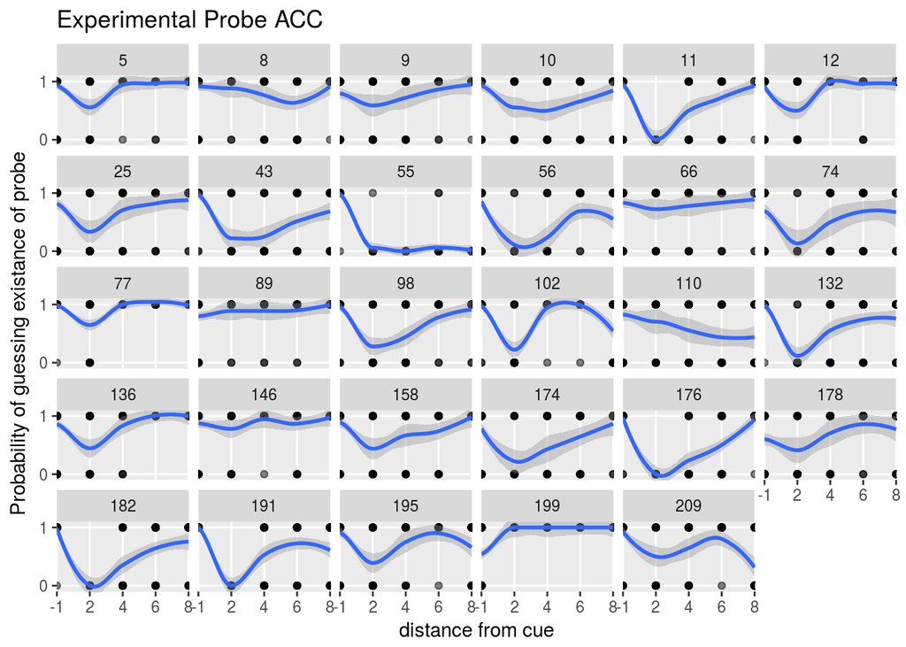

```r
#print experimental group data
g1 <- ggplot(data = AttBli_data_pre_cue_filter_experimental, aes(x = as.numeric(stimtype), y = probe_ACC))
g2 <- g1 + geom_point(alpha=.5) + geom_smooth(method='loess')
g3 <- g2 + scale_x_discrete(name = "distance from cue", limits=c("-1","2","4","6","8"))
g4 <- g3 + scale_y_discrete(name = "Probability of guessing existance of probe", limits=c(0,1))
g5 <- g4 + coord_cartesian(ylim =c(-.1,1.1), expand = FALSE) + facet_wrap(~subject) + ggtitle("Experimental Probe ACC")
print(g5)
```

**Conclusion**: Honestly, the graphs don’t look much different, so is this ouput normal?

### model probe Accuracy using logistic regression

Using the letter cue filtered data because it’s closer to what we want to test psychologically.

```r
probe_ACC_model<-glmer(probe_ACC ~ group*stimtype + (1|subject), family=binomial, data=AttBli_data_pre_cue_filter, verbose=TRUE)
```

[output not shown]

```r
summary(probe_ACC_model)
```

```
## Generalized linear mixed model fit by maximum likelihood (Laplace
##   Approximation) [glmerMod]
##  Family: binomial  ( logit )
## Formula: probe_ACC ~ group * stimtype + (1 | subject)
##    Data: AttBli_data_pre_cue_filter
##
##      AIC      BIC   logLik deviance df.resid
##   8076.4   8154.0  -4027.2   8054.4     8538
##
## Scaled residuals:
##     Min      1Q  Median      3Q     Max
## -5.8570  0.2468  0.3677  0.5072  2.3346
##
## Random effects:
##  Groups  Name        Variance Std.Dev.
##  subject (Intercept) 0.3955   0.6288
## Number of obs: 8549, groups:  subject, 62
##
## Fixed effects:
##                             Estimate Std. Error z value Pr(>|z|)
## (Intercept)                   1.8548     0.1259  14.732  < 2e-16 ***
## groupExperimental             0.2378     0.1858   1.280  0.20070
## stimtype2                    -1.5077     0.1080 -13.959  < 2e-16 ***
## stimtype4                    -0.9654     0.1124  -8.588  < 2e-16 ***
## stimtype6                    -0.3879     0.1236  -3.139  0.00170 **
## stimtype8                    -0.3002     0.1253  -2.396  0.01658 *
## groupExperimental:stimtype2  -0.9876     0.1607  -6.147 7.87e-10 ***
## groupExperimental:stimtype4  -0.5179     0.1642  -3.154  0.00161 **
## groupExperimental:stimtype6  -0.4699     0.1779  -2.641  0.00827 **
## groupExperimental:stimtype8  -0.3916     0.1823  -2.147  0.03176 *
## ---
## Signif. codes:  0 '***' 0.001 '**' 0.01 '*' 0.05 '.' 0.1 ' ' 1
##
## Correlation of Fixed Effects:
##             (Intr) grpExp stmty2 stmty4 stmty6 stmty8 grpE:2 grpE:4 grpE:6
## grpExprmntl -0.676
## stimtype2   -0.281  0.189
## stimtype4   -0.264  0.178  0.308
## stimtype6   -0.236  0.159  0.275  0.263
## stimtype8   -0.231  0.157  0.269  0.258  0.234
## grpExprmn:2  0.187 -0.299 -0.670 -0.206 -0.184 -0.181
## grpExprmn:4  0.180 -0.286 -0.210 -0.684 -0.180 -0.177  0.332
## grpExprmn:6  0.163 -0.259 -0.190 -0.182 -0.695 -0.163  0.300  0.292
## grpExprmn:8  0.159 -0.252 -0.185 -0.177 -0.161 -0.687  0.293  0.285  0.262
```

**Conclusion**: there is no overall group effect (as expected), but there are some interactions between group and how large the distance between cue and probe was. These may warrant further investigation.

### Print letter cue accuracy data

There were four choices so random guessing should give about 25% correct

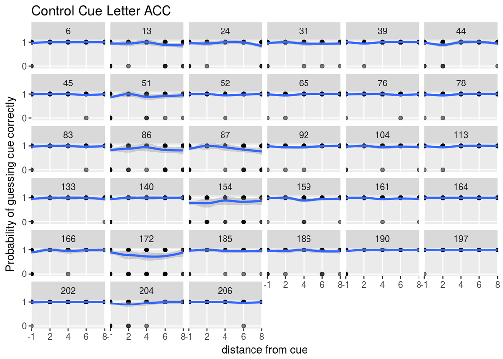

```r
AttBli_data_pre_control <- subset(AttBli_data_pre, group=="Control")
AttBli_data_pre_experimental <- subset(AttBli_data_pre, group=="Experimental")

g1 <- ggplot(data = AttBli_data_pre_control, aes(x = as.numeric(AttBli_data_pre_control$stimtype), y = AttBli_data_pre_control$letter_ACC))
g2 <- g1 + geom_point(alpha=.5) + geom_smooth(method='loess')
g3 <- g2 + scale_x_discrete(name = "distance from cue", limits=c("-1","2","4","6","8"))
g4 <- g3 + scale_y_discrete(name = "Probability of guessing cue correctly", limits=c(0,1))
g5 <- g4 + coord_cartesian(ylim =c(-.1,1.1), expand = FALSE) + facet_wrap(~subject) + ggtitle("Control Cue Letter ACC")
print(g5)
```

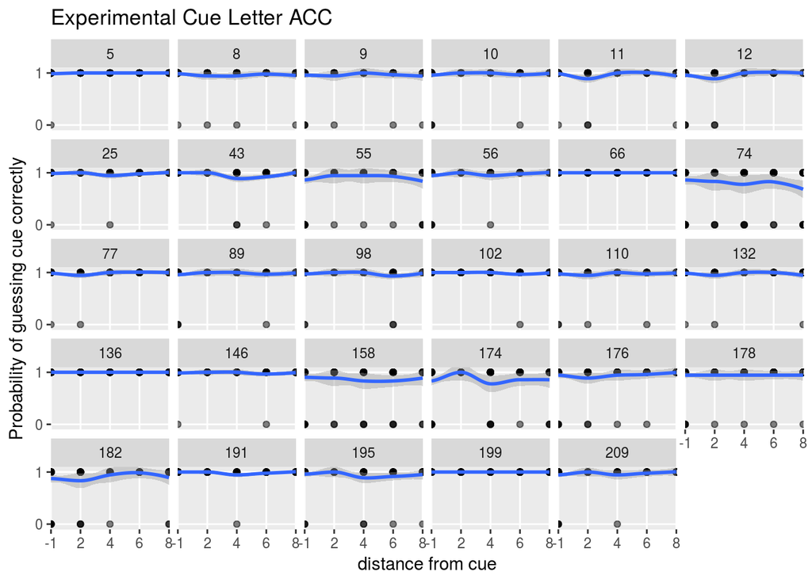

```r
g1 <- ggplot(data = AttBli_data_pre_experimental, aes(x = as.numeric(AttBli_data_pre_experimental$stimtype), y = AttBli_data_pre_experimental$letter_ACC))
g2 <- g1 + geom_point(alpha=.5) + geom_smooth(method='loess')
g3 <- g2 + scale_x_discrete(name = "distance from cue", limits=c("-1","2","4","6","8"))
g4 <- g3 + scale_y_discrete(name = "Probability of guessing cue correctly", limits=c(0,1))
g5 <- g4 + coord_cartesian(ylim =c(-.1,1.1), expand = FALSE) + facet_wrap(~subject) + ggtitle("Experimental Cue Letter ACC")
print(g5)
```

**Conclusion**: Participants were generally accurate reporting the identity of the letter cue.

### Model letter accuracy with logistic regression

```r
letter_ACC_model<-glmer(AttBli_data_pre$letter_ACC ~ group*stimtype + (1|subject), family=binomial, data=AttBli_data_pre, verbose=TRUE)
```

[output not shown]

[output cut: 30 more lines]

[output not shown]

```r
summary(letter_ACC_model)
```

```
## Generalized linear mixed model fit by maximum likelihood (Laplace
##   Approximation) [glmerMod]
##  Family: binomial  ( logit )
## Formula: AttBli_data_pre$letter_ACC ~ group * stimtype + (1 | subject)
##    Data: AttBli_data_pre
##
##      AIC      BIC   logLik deviance df.resid
##   2938.8   3016.9  -1458.4   2916.8     8917
##
## Scaled residuals:
##     Min      1Q  Median      3Q     Max
## -9.6810  0.1206  0.1652  0.2117  0.4826
##
## Random effects:
##  Groups  Name        Variance Std.Dev.
##  subject (Intercept) 0.9253   0.9619
## Number of obs: 8928, groups:  subject, 62
##
## Fixed effects:
##                             Estimate Std. Error z value Pr(>|z|)
## (Intercept)                  3.47799    0.20476  16.986   <2e-16 ***
## groupExperimental            0.03015    0.29621   0.102    0.919
## stimtype2                    0.21308    0.23883   0.892    0.372
## stimtype4                    0.26313    0.24308   1.082    0.279
## stimtype6                   -0.05087    0.21835  -0.233    0.816
## stimtype8                    0.07398    0.22760   0.325    0.745
## groupExperimental:stimtype2 -0.13846    0.34357  -0.403    0.687
## groupExperimental:stimtype4 -0.33390    0.33824  -0.987    0.324
## groupExperimental:stimtype6  0.23388    0.33683   0.694    0.487
## groupExperimental:stimtype8 -0.04958    0.33279  -0.149    0.882
## ---
## Signif. codes:  0 '***' 0.001 '**' 0.01 '*' 0.05 '.' 0.1 ' ' 1
##
## Correlation of Fixed Effects:
##             (Intr) grpExp stmty2 stmty4 stmty6 stmty8 grpE:2 grpE:4 grpE:6
## grpExprmntl -0.673
## stimtype2   -0.200  0.138
## stimtype4   -0.196  0.136  0.170
## stimtype6   -0.221  0.153  0.189  0.186
## stimtype8   -0.211  0.146  0.181  0.178  0.198
## grpExprmn:2  0.139 -0.210 -0.695 -0.118 -0.131 -0.126
## grpExprmn:4  0.141 -0.213 -0.122 -0.719 -0.133 -0.128  0.185
## grpExprmn:6  0.143 -0.215 -0.123 -0.120 -0.648 -0.128  0.185  0.188
## grpExprmn:8  0.144 -0.217 -0.124 -0.122 -0.136 -0.684  0.188  0.191  0.191
## convergence code: 0
## Model failed to converge with max|grad| = 0.00284121 (tol = 0.001, component 1)
```

**Conclusion**: Both groups had similar accuracy identifying the white letter cue across cue-probe distances (as expected)

## AttBli Reaction Time Analysis

### Format RT data

(subset for RTs when they are accurate, greater than 200ms, and less than 3000 ms) ^The above thresholds were set somewhat arbitrarily, you can play with the thresholds. See how many observations are lost when we subset the data

```r
#all observations
print("All Data")
```

```
## [1] "All Data"
```

```r
All_data_probe <- length(AttBli_data_pre$probe_RT)
summary(AttBli_data_pre)
```

```
##     subject     session           group      stimtype    letter_ACC
##  5      : 144   1:8928   Control     :4752   -1:4464   Min.   :0.0000
##  6      : 144            Experimental:4176   2 :1116   1st Qu.:1.0000
##  8      : 144                                4 :1116   Median :1.0000
##  9      : 144                                6 :1116   Mean   :0.9575
##  10     : 144                                8 :1116   3rd Qu.:1.0000
##  11     : 144                                          Max.   :1.0000
##  (Other):8064
##    letter_RT       probe_ACC         probe_RT
##  Min.   :   60   Min.   :0.0000   Min.   :  140.0
##  1st Qu.: 1125   1st Qu.:1.0000   1st Qu.:  454.0
##  Median : 1345   Median :1.0000   Median :  660.5
##  Mean   : 1553   Mean   :0.7678   Mean   :  864.6
##  3rd Qu.: 1676   3rd Qu.:1.0000   3rd Qu.: 1029.0
##  Max.   :30189   Max.   :1.0000   Max.   :24138.0
##
```

```r
#remove innacurate responses
print("Removed innacurate probe trials (from all data dataframe)")
```

```
## [1] "Removed innacurate probe trials (from all data dataframe)"
```

```r
AttBli_data_pre_probe_RT <- subset(AttBli_data_pre, probe_ACC==1)
All_Accurate_data_probe <- length(AttBli_data_pre_probe_RT$probe_RT)
summary(AttBli_data_pre_probe_RT)
```

```
##     subject     session           group      stimtype    letter_ACC
##  77     : 136   1:6855   Control     :3700   -1:3837   Min.   :0.0000
##  45     : 133            Experimental:3155   2 : 553   1st Qu.:1.0000
##  65     : 133                                4 : 736   Median :1.0000
##  172    : 132                                6 : 858   Mean   :0.9664
##  166    : 129                                8 : 871   3rd Qu.:1.0000
##  5      : 128                                          Max.   :1.0000
##  (Other):6064
##    letter_RT       probe_ACC    probe_RT
##  Min.   :   60   Min.   :1   Min.   :  140.0
##  1st Qu.: 1109   1st Qu.:1   1st Qu.:  459.0
##  Median : 1322   Median :1   Median :  658.0
##  Mean   : 1510   Mean   :1   Mean   :  843.2
##  3rd Qu.: 1635   3rd Qu.:1   3rd Qu.:  999.0
##  Max.   :30189   Max.   :1   Max.   :24138.0
##
```

```r
#remove short and long RTs
print("Removed slow and fast RTs")
```

```
## [1] "Removed slow and fast RTs"
```

```r
AttBli_data_pre_probe_RT <- subset(AttBli_data_pre_probe_RT, probe_RT>200 & probe_RT<3000)
filtered_data_probe <- length(AttBli_data_pre_probe_RT$probe_RT)
summary(AttBli_data_pre_probe_RT)
```

```
##     subject     session           group      stimtype    letter_ACC
##  77     : 134   1:6719   Control     :3642   -1:3755   Min.   :0.0000
##  45     : 133            Experimental:3077   2 : 545   1st Qu.:1.0000
##  65     : 133                                4 : 723   Median :1.0000
##  172    : 130                                6 : 847   Mean   :0.9687
##  166    : 128                                8 : 849   3rd Qu.:1.0000
##  5      : 127                                          Max.   :1.0000
##  (Other):5934
##    letter_RT       probe_ACC    probe_RT
##  Min.   :   60   Min.   :1   Min.   : 201.0
##  1st Qu.: 1108   1st Qu.:1   1st Qu.: 461.0
##  Median : 1320   Median :1   Median : 657.0
##  Mean   : 1493   Mean   :1   Mean   : 798.6
##  3rd Qu.: 1632   3rd Qu.:1   3rd Qu.: 979.5
##  Max.   :26131   Max.   :1   Max.   :2973.0
##
```

```r
print("Percentage Probe Data Removed")
```

```
## [1] "Percentage Probe Data Removed"
```

```r
percent_data_rm_probe <- (1 - (filtered_data_probe/All_Accurate_data_probe)) * 100
percent_data_rm_probe
```

```
## [1] 1.983953
```

```r
#remove innacurate responses
print("Removed innacurate letter trials (from all data dataframe")
```

```
## [1] "Removed innacurate letter trials (from all data dataframe"
```

```r
AttBli_data_pre_letter_RT <- subset(AttBli_data_pre, letter_ACC==1)
All_Accurate_data_cue <- length(AttBli_data_pre_letter_RT$letter_RT)
summary(AttBli_data_pre_letter_RT)
```

```
##     subject     session           group      stimtype    letter_ACC
##  66     : 144   1:8549   Control     :4549   -1:4267   Min.   :1
##  136    : 144            Experimental:4000   2 :1073   1st Qu.:1
##  185    : 144                                4 :1071   Median :1
##  199    : 144                                6 :1069   Mean   :1
##  5      : 143                                8 :1069   3rd Qu.:1
##  39     : 143                                          Max.   :1
##  (Other):7687
##    letter_RT       probe_ACC         probe_RT
##  Min.   :   60   Min.   :0.0000   Min.   :  140.0
##  1st Qu.: 1121   1st Qu.:1.0000   1st Qu.:  453.0
##  Median : 1332   Median :1.0000   Median :  655.0
##  Mean   : 1477   Mean   :0.7749   Mean   :  848.6
##  3rd Qu.: 1637   3rd Qu.:1.0000   3rd Qu.: 1009.0
##  Max.   :17024   Max.   :1.0000   Max.   :24138.0
##
```

```r
#remove short and long RTs
print("Removed slow and fast RTs")
```

```
## [1] "Removed slow and fast RTs"
```

```r
AttBli_data_pre_letter_RT <- subset(AttBli_data_pre_probe_RT, letter_RT>200 & letter_RT<3000)
filtered_data_cue <- length(AttBli_data_pre_letter_RT$letter_RT)
summary(AttBli_data_pre_letter_RT)
```

```
##     subject     session           group      stimtype    letter_ACC
##  45     : 130   1:6510   Control     :3538   -1:3613   Min.   :0.000
##  65     : 130            Experimental:2972   2 : 529   1st Qu.:1.000
##  172    : 130                                4 : 711   Median :1.000
##  77     : 127                                6 : 831   Mean   :0.978
##  166    : 127                                8 : 826   3rd Qu.:1.000
##  5      : 126                                          Max.   :1.000
##  (Other):5740
##    letter_RT      probe_ACC    probe_RT
##  Min.   : 331   Min.   :1   Min.   : 201.0
##  1st Qu.:1100   1st Qu.:1   1st Qu.: 458.0
##  Median :1306   Median :1   Median : 650.0
##  Mean   :1384   Mean   :1   Mean   : 781.5
##  3rd Qu.:1598   3rd Qu.:1   3rd Qu.: 950.0
##  Max.   :2995   Max.   :1   Max.   :2973.0
##
```

```r
print("Percentage Cue Data Removed")
```

```
## [1] "Percentage Cue Data Removed"
```

```r
percent_data_rm_cue <- (1 - (filtered_data_cue/All_Accurate_data_cue)) * 100
percent_data_rm_cue
```

```
## [1] 23.85074
```

**Conclusion**: take a deeper look at the letter RTs to see what’s going on, way too many data cut off (about 24%)

### Graph probe RT data

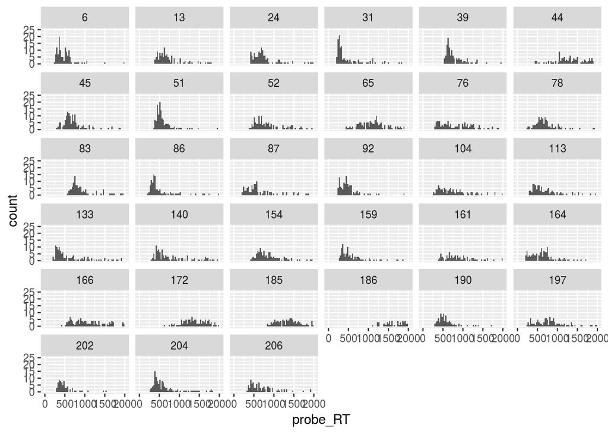

```r
AttBli_data_pre_probe_RT_control <- subset(AttBli_data_pre_probe_RT, group=="Control")

AttBli_data_pre_probe_RT_experimental <- subset(AttBli_data_pre_probe_RT, group=="Experimental")


RT_hist_control <- ggplot(data = AttBli_data_pre_probe_RT_control, aes(probe_RT)) + geom_histogram(binwidth = 30) + facet_wrap(~subject) + scale_y_continuous(limits = c(0,25)) + scale_x_continuous(limits = c(0,2000))
print(RT_hist_control)
```

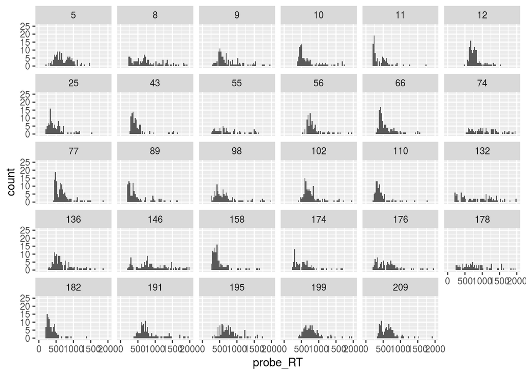

```r
RT_hist_experimental <- ggplot(data = AttBli_data_pre_probe_RT_experimental, aes(probe_RT)) + geom_histogram(binwidth = 30) + facet_wrap(~subject) + scale_y_continuous(limits = c(0,25)) + scale_x_continuous(limits = c(0,2000))
print(RT_hist_experimental)
```

**Conclusion**: Most participants show a right skew, going to log transform the data to see if they look better.

### Log transform RT data

```r
AttBli_data_pre_probe_RT$log_probe_RT <- log(1/AttBli_data_pre_probe_RT$probe_RT)
AttBli_data_pre_letter_RT$log_letter_RT <- log(1/AttBli_data_pre_letter_RT$letter_RT)
```

### Graph Log_probe_RT data

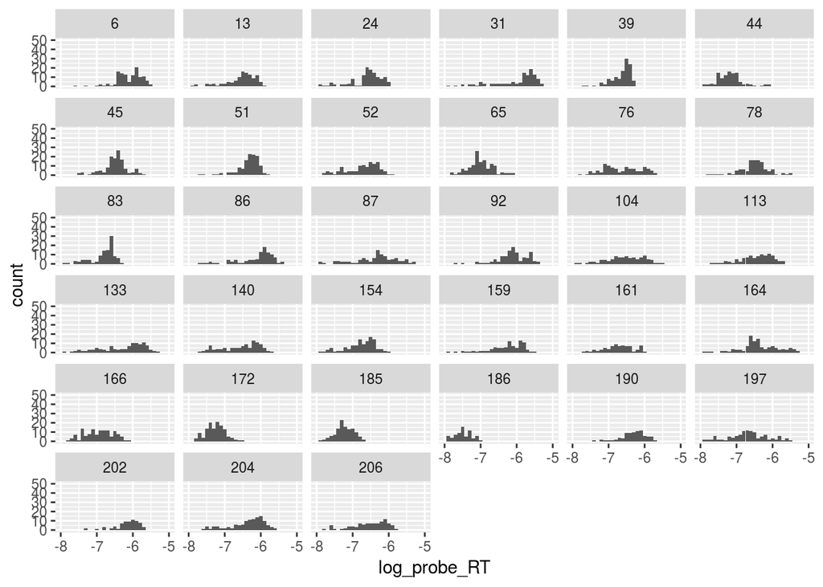

```r
AttBli_data_pre_probe_RT_control <- subset(AttBli_data_pre_probe_RT, group=="Control")

AttBli_data_pre_probe_RT_experimental <- subset(AttBli_data_pre_probe_RT, group=="Experimental")

#collapsing across stimtype (-1,2,4,6,8), not enough data to make a good histogram, and the graphs become too crowded if I include stimtype as a facet
RT_hist_control <- ggplot(data = AttBli_data_pre_probe_RT_control, aes(log_probe_RT)) + geom_histogram(binwidth = .1) + facet_wrap(~subject) + scale_y_continuous(limits = c(0,50)) + scale_x_continuous(limits = c(-8,-5))
print(RT_hist_control)
```

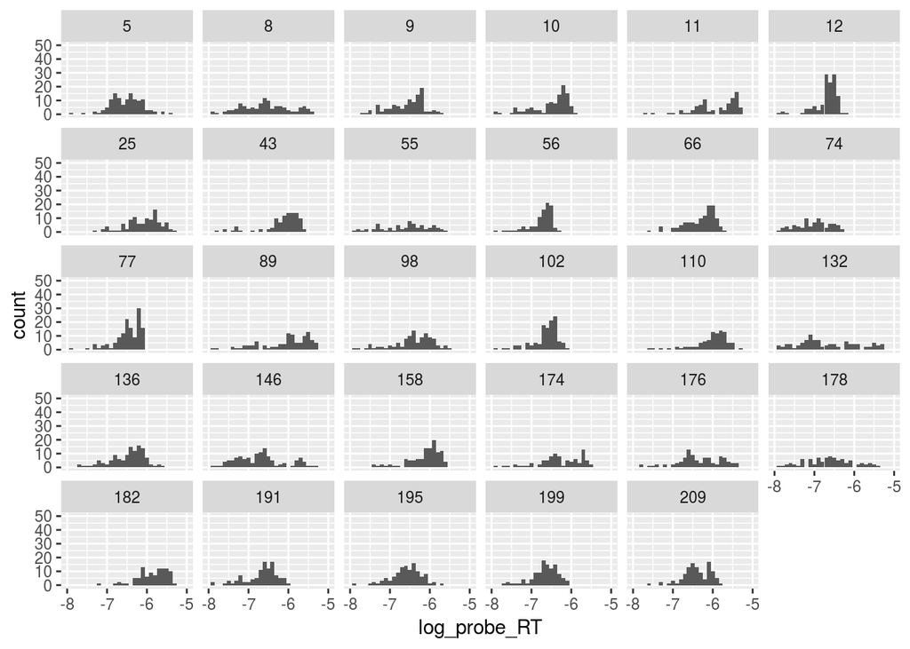

```r
RT_hist_experimental <- ggplot(data = AttBli_data_pre_probe_RT_experimental, aes(log_probe_RT)) + geom_histogram(binwidth = .1) + facet_wrap(~subject) + scale_y_continuous(limits = c(0,50)) + scale_x_continuous(limits = c(-8,-5))
print(RT_hist_experimental)
```

**Conclusion**: Probe Data overall looks more normally distributed.

### Model log Probe RT

```r
probe_RT_model <- lmer(log_probe_RT ~ group*stimtype + (1|subject), data = AttBli_data_pre_probe_RT)
summary(probe_RT_model)
```

```
## Linear mixed model fit by REML t-tests use Satterthwaite approximations
##   to degrees of freedom [lmerMod]
## Formula: log_probe_RT ~ group * stimtype + (1 | subject)
##    Data: AttBli_data_pre_probe_RT
##
## REML criterion at convergence: 8676.4
##
## Scaled residuals:
##     Min      1Q  Median      3Q     Max
## -4.1620 -0.5122  0.1335  0.6472  3.0201
##
## Random effects:
##  Groups   Name        Variance Std.Dev.
##  subject  (Intercept) 0.1045   0.3232
##  Residual             0.2040   0.4516
## Number of obs: 6719, groups:  subject, 62
##
## Fixed effects:
##                               Estimate Std. Error         df  t value
## (Intercept)                   -6.57553    0.05719   62.00000 -114.973
## groupExperimental              0.15726    0.08360   62.00000    1.881
## stimtype2                      0.01152    0.02691 6656.00000    0.428
## stimtype4                     -0.03676    0.02494 6653.00000   -1.474
## stimtype6                     -0.01531    0.02340 6652.00000   -0.654
## stimtype8                     -0.05189    0.02355 6652.00000   -2.204
## groupExperimental:stimtype2   -0.03729    0.04316 6657.00000   -0.864
## groupExperimental:stimtype4   -0.02027    0.03721 6654.00000   -0.545
## groupExperimental:stimtype6   -0.01314    0.03470 6652.00000   -0.379
## groupExperimental:stimtype8   -0.05128    0.03465 6653.00000   -1.480
##                             Pr(>|t|)
## (Intercept)                   <2e-16 ***
## groupExperimental             0.0647 .
## stimtype2                     0.6685
## stimtype4                     0.1406
## stimtype6                     0.5131
## stimtype8                     0.0276 *
## groupExperimental:stimtype2   0.3876
## groupExperimental:stimtype4   0.5859
## groupExperimental:stimtype6   0.7049
## groupExperimental:stimtype8   0.1390
## ---
## Signif. codes:  0 '***' 0.001 '**' 0.01 '*' 0.05 '.' 0.1 ' ' 1
##
## Correlation of Fixed Effects:
##             (Intr) grpExp stmty2 stmty4 stmty6 stmty8 grpE:2 grpE:4 grpE:6
## grpExprmntl -0.684
## stimtype2   -0.070  0.048
## stimtype4   -0.074  0.051  0.169
## stimtype6   -0.078  0.054  0.175  0.186
## stimtype8   -0.079  0.054  0.173  0.183  0.193
## grpExprmn:2  0.043 -0.062 -0.624 -0.105 -0.109 -0.108
## grpExprmn:4  0.050 -0.072 -0.113 -0.670 -0.125 -0.123  0.154
## grpExprmn:6  0.053 -0.076 -0.118 -0.126 -0.674 -0.130  0.156  0.180
## grpExprmn:8  0.053 -0.077 -0.118 -0.124 -0.131 -0.679  0.157  0.179  0.189
```

### Model logged letter RT by group and lag

```r
letter_RT_model <- lmer(log_letter_RT ~ group*stimtype + (1|subject), data = AttBli_data_pre_letter_RT)
summary(letter_RT_model)
```

```
## Linear mixed model fit by REML t-tests use Satterthwaite approximations
##   to degrees of freedom [lmerMod]
## Formula: log_letter_RT ~ group * stimtype + (1 | subject)
##    Data: AttBli_data_pre_letter_RT
##
## REML criterion at convergence: 855.2
##
## Scaled residuals:
##     Min      1Q  Median      3Q     Max
## -4.4376 -0.5385  0.1349  0.6404  5.2683
##
## Random effects:
##  Groups   Name        Variance Std.Dev.
##  subject  (Intercept) 0.02397  0.1548
##  Residual             0.06394  0.2529
## Number of obs: 6510, groups:  subject, 62
##
## Fixed effects:
##                               Estimate Std. Error         df  t value
## (Intercept)                 -7.246e+00  2.758e-02  6.200e+01 -262.708
## groupExperimental            2.337e-02  4.031e-02  6.200e+01    0.580
## stimtype2                    1.543e-01  1.527e-02  6.449e+03   10.104
## stimtype4                    1.764e-01  1.409e-02  6.446e+03   12.519
## stimtype6                    1.306e-01  1.325e-02  6.443e+03    9.854
## stimtype8                    2.321e-02  1.337e-02  6.444e+03    1.737
## groupExperimental:stimtype2 -4.036e-02  2.459e-02  6.451e+03   -1.642
## groupExperimental:stimtype4 -9.116e-03  2.106e-02  6.447e+03   -0.433
## groupExperimental:stimtype6 -9.662e-03  1.965e-02  6.445e+03   -0.492
## groupExperimental:stimtype8 -3.689e-02  1.970e-02  6.446e+03   -1.872
##                             Pr(>|t|)
## (Intercept)                   <2e-16 ***
## groupExperimental             0.5642
## stimtype2                     <2e-16 ***
## stimtype4                     <2e-16 ***
## stimtype6                     <2e-16 ***
## stimtype8                     0.0825 .
## groupExperimental:stimtype2   0.1007
## groupExperimental:stimtype4   0.6652
## groupExperimental:stimtype6   0.6229
## groupExperimental:stimtype8   0.0612 .
## ---
## Signif. codes:  0 '***' 0.001 '**' 0.01 '*' 0.05 '.' 0.1 ' ' 1
##
## Correlation of Fixed Effects:
##             (Intr) grpExp stmty2 stmty4 stmty6 stmty8 grpE:2 grpE:4 grpE:6
## grpExprmntl -0.684
## stimtype2   -0.083  0.056
## stimtype4   -0.089  0.061  0.171
## stimtype6   -0.093  0.064  0.177  0.189
## stimtype8   -0.093  0.064  0.175  0.186  0.195
## grpExprmn:2  0.051 -0.074 -0.621 -0.106 -0.110 -0.109
## grpExprmn:4  0.059 -0.086 -0.115 -0.669 -0.127 -0.124  0.156
## grpExprmn:6  0.063 -0.091 -0.119 -0.128 -0.674 -0.132  0.158  0.184
## grpExprmn:8  0.063 -0.091 -0.119 -0.126 -0.132 -0.678  0.159  0.182  0.192
```

**Conclusion**: No group effect (as expected), but there is another trending RT difference at the largest cue-probe difference. Not going to read too much into this until I figure out why 23% of the letter cue RT data was so long!

## Conclusions

Good: No overall Group differences in Reaction Time or Accuracy